# TELG1011 - Practica de Laboratorio #5

Nombres y Apellidos: Marco Arizala

Fecha: Noviembre 23, 2018

```python
%pylab inline

%matplotlib inline
from scipy import signal
import numpy as np
import dspfunc as dsp
```

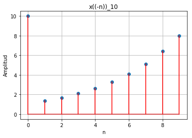

```python
n = np.arange(0,10,1) # creamos el rango de la secuencia donde no incluimos el 10
secx=10*np.power(0.8, n)
secxflip = secx[np.mod(-n, 10)] #transformamos a x((-n))_10
stem(n, secxflip,'r')
title('x((-n))_10')
xlabel('n')
ylabel('Amplitud')
grid ()
```

### DFT

```
Text(0,0.5,'Amplitud')
```

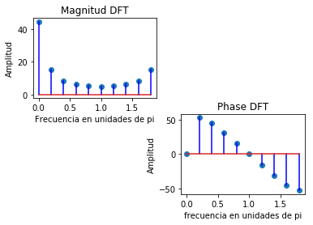

```python
xdft = dsp.dft(secxflip,10)
magxdft = np.abs(xdft)
phasexdft = dsp.np.angle(xdft) * 180/np.pi # lo convertimos a grados

wwm = 2*np.pi/10 * n # frecuencias en unidades de pi

#Graficos
subplot(2, 2, 1)

stem(wwm/np.pi,magxdft,'b')
title('Magnitud DFT')
xlabel('Frecuencia en unidades de pi')
ylabel('Amplitud')


subplot(2, 2, 4)

stem(wwm/np.pi,phasexdft,'b')
title('Phase DFT')
xlabel('frecuencia en unidades de pi')
ylabel('Amplitud')
```

DFT Senal Analogica

```
Text(0,0.5,'Amplitud')
```

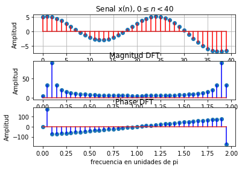

```python
N=40

n = np.arange(0,N,1) # creamos el rango de la secuencia donde no incluimos el 10
secx=(2*sin(4*pi*0.01*n)) + (5*cos(8*pi*0.01*n))



xdft = dsp.dft(secx,N)
magxdft = np.abs(xdft)
phasexdft = dsp.np.angle(xdft) * 180/np.pi # lo convertimos a grados

wwm = 2*np.pi/N * n # frecuencias en unidades de pi

#Graficos
subplot(3, 1, 1)

stem(n, secx,'r')
title('Senal x(n), $0 \leq n < 40$')
xlabel('n')
ylabel('Amplitud')
grid ()


subplot(3, 1, 2)

stem(wwm/np.pi,magxdft,'b')
title('Magnitud DFT')
xlabel('Frecuencia en unidades de pi')
ylabel('Amplitud')

subplot(3, 1, 3)

stem(wwm/np.pi,phasexdft,'b')
title('Phase DFT')
xlabel('frecuencia en unidades de pi')
ylabel('Amplitud')
```

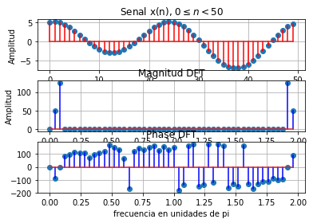

```python
N=50

n = np.arange(0,N,1) # creamos el rango de la secuencia donde no incluimos el 10
secx=(2*sin(4*pi*0.01*n)) + (5*cos(8*pi*0.01*n))



xdft = dsp.dft(secx,N)
magxdft = np.abs(xdft)
phasexdft = dsp.np.angle(xdft) * 180/np.pi # lo convertimos a grados

wwm = 2*np.pi/N * n # frecuencias en unidades de pi

#Graficos
subplot(3, 1, 1)

stem(n, secx,'r')
title('Senal x(n), $0 \leq n < 50$')
xlabel('n')
ylabel('Amplitud')
grid ()


subplot(3, 1, 2)

stem(wwm/np.pi,magxdft,'b')
title('Magnitud DFT')
xlabel('Frecuencia en unidades de pi')
ylabel('Amplitud')
grid ()

subplot(3, 1, 3)

stem(wwm/np.pi,phasexdft,'b')
title('Phase DFT')
xlabel('frecuencia en unidades de pi')
ylabel('')
grid ()
```

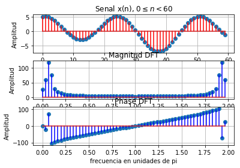

```python
N=60

n = np.arange(0,N,1) # creamos el rango de la secuencia donde no incluimos el 10
secx=(2*sin(4*pi*0.01*n)) + (5*cos(8*pi*0.01*n))



xdft = dsp.dft(secx,N)
magxdft = np.abs(xdft)
phasexdft = dsp.np.angle(xdft) * 180/np.pi # lo convertimos a grados

wwm = 2*np.pi/N * n # frecuencias en unidades de pi

#Graficos
subplot(3, 1, 1)

stem(n, secx,'r')
title('Senal x(n), $0 \leq n < 60$')
xlabel('n')
ylabel('Amplitud')
grid ()


subplot(3, 1, 2)

stem(wwm/np.pi,magxdft,'b')
title('Magnitud DFT')
xlabel('Frecuencia en unidades de pi')
ylabel('Amplitud')
grid ()

subplot(3, 1, 3)

stem(wwm/np.pi,phasexdft,'b')
title('Phase DFT')
xlabel('frecuencia en unidades de pi')
ylabel('Amplitud')
grid ()
```

b)

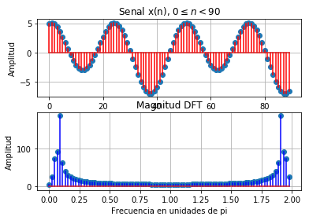

```python
N=90

n = np.arange(0,N,1) # creamos el rango de la secuencia donde no incluimos el 10
secx=(2*sin(4*pi*0.01*n)) + (5*cos(8*pi*0.01*n))



xdft = dsp.dft(secx,N)
magxdft = np.abs(xdft)
phasexdft = dsp.np.angle(xdft) * 180/np.pi # lo convertimos a grados

wwm = 2*np.pi/N * n # frecuencias en unidades de pi

#Graficos
subplot(2, 1, 1)

stem(n, secx,'r')
title('Senal x(n), $0 \leq n < 90$')
xlabel('n')
ylabel('Amplitud')
grid ()


subplot(2, 1, 2)

stem(wwm/np.pi,magxdft,'b')
title('Magnitud DFT')
xlabel('Frecuencia en unidades de pi')
ylabel('Amplitud')
grid ()
```

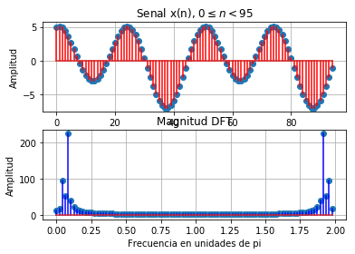

```python
N=95

n = np.arange(0,N,1) # creamos el rango de la secuencia donde no incluimos el 10
secx=(2*sin(4*pi*0.01*n)) + (5*cos(8*pi*0.01*n))



xdft = dsp.dft(secx,N)
magxdft = np.abs(xdft)
phasexdft = dsp.np.angle(xdft) * 180/np.pi # lo convertimos a grados

wwm = 2*np.pi/N * n # frecuencias en unidades de pi

#Graficos
subplot(2, 1, 1)

stem(n, secx,'r')
title('Senal x(n), $0 \leq n < 95$')
xlabel('n')
ylabel('Amplitud')
grid ()


subplot(2, 1, 2)

stem(wwm/np.pi,magxdft,'b')
title('Magnitud DFT')
xlabel('Frecuencia en unidades de pi')
ylabel('Amplitud')
grid ()
```

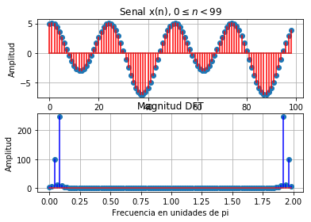

```python
N=99

n = np.arange(0,N,1) # creamos el rango de la secuencia donde no incluimos el 10
secx=(2*sin(4*pi*0.01*n)) + (5*cos(8*pi*0.01*n))



xdft = dsp.dft(secx,N)
magxdft = np.abs(xdft)
phasexdft = dsp.np.angle(xdft) * 180/np.pi # lo convertimos a grados

wwm = 2*np.pi/N * n # frecuencias en unidades de pi

#Graficos
subplot(2, 1, 1)

stem(n, secx,'r')
title('Senal x(n), $0 \leq n < 99$')
xlabel('n')
ylabel('Amplitud')
grid ()


subplot(2, 1, 2)

stem(wwm/np.pi,magxdft,'b')
title('Magnitud DFT')
xlabel('Frecuencia en unidades de pi')
ylabel('Amplitud')
grid ()
```

### Ventanas

```python
NN=128
tn = np.arange(0, NN)
senal= 10*np.cos(0.28*np.pi*tn) + 0.5*np.cos(0.3125*np.pi*tn)


#Ventana triangular
Ttn = signal.triang(NN)
#Ventana hanning
Hhn = signal.hanning(NN)

xxtriangular= senal*Ttn
xxhanning= senal*Hhn
```

```
Text(0,0.5,'Ventana hanning')
```

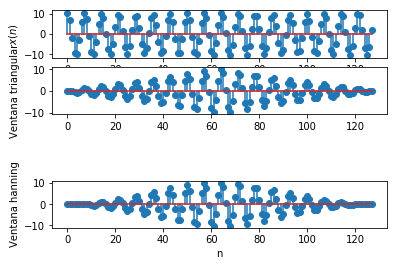

```python
#GRAFICAS
subplot(4, 1, 1)
stem(tn, senal)
ylabel('$x(n)$')

subplot(4, 1, 2)
stem(tn, xxtriangular)
ylabel('Ventana triangular')

subplot(4, 1, 4)
stem(tn, xxhanning)
xlabel('n')
ylabel('Ventana hanning')
```

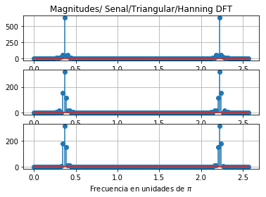

```python
NN=128
a = dsp.dft(senal,NN)
magsenal = np.abs(a)

b = dsp.dft(xxtriangular,NN)
magxxtriangul = np.abs(b)

c= dsp.dft(xxhanning,NN)
magxxhanning = np.abs(c)


wwm = 2*np.pi/N * tn

# Magnitudes de la Dft

#Senal
subplot(3, 1, 1)
stem(wwm/np.pi,magsenal)
title('Magnitudes/ Senal/Triangular/Hanning DFT')
grid ()


#Ventana Triangular
subplot(3, 1, 2)
stem(wwm/np.pi,magxxtriangul)
grid ()

#Ventana Hanning
subplot(3, 1, 3)
stem(wwm/np.pi,magxxhanning)
xlabel('Frecuencia en unidades de $\pi$')
grid ()
```

- La ventana Hanning reduce mas el efecto leakage que la ventana triangular
- La ventana Triangular es una combinacion , puede decirse que no cancela todo efecto leakage pero tampoco elimina todos los lobulos que quedan de la senal , debido a que no es ni muy ancha ni muy angosta

## Conclusiones

- Mediante la operacion modulo N nos permite realizar el calculo de la DFT a una secuencia de N elementos que se le ha aplicado la propiedad de la dft circular folding
- Las ventanas son utilizadas para reducir la amplitud de discontinuidades en los limites de una secuencia finita
- La ventana Hanning puede ser efectiva en un 95 porciento de los casos , posee buena resolucion en frecuencia y una baja fuga espectral a comparacion de otras ventanas .
- La ventana Hanning reduce mas el efecto leakage que la ventana triangular

## Referencias

Understanding Digital Signal Processing. (3rd. Ed.). Richard G. Lyons. (2011). Prentice Hall. Capítulo 3